# National Hockey League (NHL) Vignette

Maggie Feng June 20, 2021

- Functions to read in the data
  - NHL records API
  - NHL stats API
  - API wrapper
- Exploratory Data Analysis
  - Contingency tables
  - Bar plot
  - Numerical Summaries
  - Box plot
  - Histogram
    - Points per game
    - Win Percent
  - Scatter plot

Required packages to run this vignette:

```r
library(httr)
library(jsonlite)
library(xml2)
library(rvest)
library(tidyverse)
library(ggplot2)
library(knitr)
```

# Functions to read in the data

## NHL records API

The `getRecords` function will contact the [NHL records API](https://gitlab.com/dword4/nhlapi/-/blob/master/records-api.md), pull data from one of the six endpoints, and output a data frame.

The first argument `input` is to specify one of the six endpoints:

- `"franchise"` will return id, firstSeasonId, lastSeasonId, and name of every team in the history of the NHL
- `"teamtotal"` will return the total stats for every franchise
- `"season"` will drill-down into season records and can do so for a specific franchise
- `"goalie"` will return goalie records for all or a specified franchise
- `"skater"` will return skater records for all or a specified franchise
- `"history"` will return admin history (captains, coaches, or general managers) or retired numbers

The arguments `name` and `id` are used to specify which team’s records you wish to output. Adding `name` or `id` for the first two endpoints, `"franchise"` and `"teamtotal"`, will have the same result of not adding the arguments at all. For the third, fourth, and fifth endpoint `id` specification is based on the `franchiseId`, while the sixth endpoint `id` specification is based on the `mostRecentTeamId`. Due to possible confusion surrounding the `id` input, if the `name` input is used alongside it, `name` will override `id` when the function is run.

The final input `detail` is an argument to specify if you want to pull admin history (captains, coaches, or managers) or retired numbers. Adding this argument will not affect the first five endpoints, but is required when the `input` is `"history"`.

The `detail` argument can be:

- `"captain"` to give the captain history
- `"coach"` to give the coach history
- `"manager"` to give the general manager history
- `"player"` to give the retired numbers

```r
#Function to contact the NHL records API
getRecords <- function(input = c("franchise", "teamtotal", "season", "goalie", "skater", "history"),
                       name = NULL, id = NULL, detail = NULL){
  ##Note: if both team name and id arguments are filled, team name overrides id number

  #All queries are prefixed by this base_url
  base_url <- "https://records.nhl.com/site/api"

  #Function to convert the url
  convert <- function(url){
    x <- GET(url)                #Retrieving data from URL
    y <- content(x, as = "text") #Converiting it to JSON text
    fromJSON(y)                  #Converting to list
  }

  #First two endpoints: do not have name/id specification
  if (input == "franchise" | input == "teamtotal"){
    if (input == "franchise")
      endpoint <- "franchise"
    if (input == "teamtotal")
      endpoint <- "franchise-team-totals"
    full_url <- paste0(base_url, "/", endpoint)
    z <- convert(full_url)
    #Returns well-formatted, parsed data
    out <-as.data.frame(z$data)  #Converting to data frame
  }

  #Third, fourth, and fifth endpoints: with name/id specification by franchiseId
  if (input == "season" | input == "goalie" | input == "skater"){
    if (input == "season")
      endpoint <- "franchise-season-records"
    if (input == "goalie")
      endpoint <- "franchise-goalie-records"
    if (input == "skater")
      endpoint <- "franchise-skater-records"

    if (is.null(name) & is.null(id)){
      full_url <- paste0(base_url,"/", endpoint)
    }
    else {
      if (!is.null(id)) {
        full_url <- paste0(base_url,"/", endpoint, "?cayenneExp=franchiseId=", id)
      }
      if (!is.null(name)) {
        #Names based on franchiseId
        v <- c("Montreal Canadiens", "Montreal Wanderers", "St. Louis Eagles", "Hamilton Tigers",
               "Toronto Maple Leafs", "Boston Bruins", "Montreal Maroons", "Brooklyn Americans",
               "Philadelphia Quakers", "New York Rangers", "Chicago Blackhawks", "Detroit Red Wings",
               "Cleveland Barons", "Los Angeles Kings", "Dallas Stars", "Philadelphia Flyers",
               "Pittsburgh Penguins", "St. Louis Blues", "Buffalo Sabres", "Vancouver Canucks",
               "Calgary Flames", "New York Islanders", "New Jersey Devils", "Washington Capitals",
               "Edmonton Oilers", "Carolina Hurricanes", "Colorado Avalanche", "Arizona Coyotes",
               "San Jose Sharks", "Ottawa Senators", "Tampa Bay Lightning", "Anaheim Ducks",
               "Florida Panthers", "Nashville Predators", "Winnipeg Jets", "Columbus Blue Jackets",
               "Minnesota Wild", "Vegas Golden Knights", "Seattle Kraken")
        #Gives the number corresponding the position of the team name in vector v
        nameid <- match(name, v)
        full_url <- paste0(base_url,"/", endpoint,"?cayenneExp=franchiseId=", nameid)
      }
    }
    z <- convert(full_url)
    #Returns well-formatted, parsed data
    out <-as.data.frame(z$data)  #Converting to data frame
  }

  #Sixth endpoint: has name/id specification by mostRecentTeamId instead of franchiseId
  if (input == "history"){
    endpoint <- "franchise-detail"
    if (is.null(name) & is.null(id)){
      stop("Need to specify team")
    }
    else {
      if (!is.null(id)) {
        full_url <- paste0(base_url, "/", endpoint, "?cayenneExp=mostRecentTeamId=", id)
      }
      if (!is.null(name)) {
        #Names based on order of mostRecentTeamId
        u <- c("New Jersey Devils", "New York Islanders", "New York Rangers", "Philadelphia Flyers",
               "Pittsburgh Penguins", "Boston Bruins", "Buffalo Sabres", "Montreal Canadiens",
               "Ottawa Senators", "Toronto Maple Leafs", "Carolina Hurricanes", "Florida Panthers",
               "Tampa Bay Lightning", "Washington Capitals", "Chicago Blackhawks",
               "Detroit Red Wings", "Nashville Predators", "St. Louis Blues", "Calgary Flames",
               "Colorado Avalanche", "Edmonton Oilers", "Vancouver Canucks", "Anaheim Ducks",
               "Dallas Stars","Los Angeles Kings", "San Jose Sharks", "Columbus Blue Jackets",
               "Minnesota Wild", "Hamilton Tigers", "Philadelphia Quakers", "Montreal Wanderers",
               "Montreal Maroons","St. Louis Eagles", "Cleveland Barons", "Brooklyn Americans",
               "Winnipeg Jets", "Arizona Coyotes", "Vegas Golden Knights", "Seattle Kraken")
        #Gives the number corresponding the position of the team name in vector v
        nameid <- match(name, u)
        #Numbers corresponding to mostRecentTeamId for teams in vector u
        unum <- c(1:10, 12:30, seq(37,45,by=2), 49, 51:55)
        full_url <- paste0(base_url,"/", endpoint, "?cayenneExp=mostRecentTeamId=", unum[nameid])
      }
    }
    z <- convert(full_url)
    #Converting to data frame
    a <- as.data.frame(z$data)

    #Output error if detail is not given for "history" input
    if (is.null(detail)){
      stop("Need to specify detail: captain, coach, manager, or player")
    }

    #Selecting which detail you want
    if (detail == "captain")
      b <- a$captainHistory
    if (detail == "coach")
      b <- a$coachingHistory
    if (detail == "manager")
      b <- a$generalManagerHistory
    if (detail == "player")
      b <- a$retiredNumbersSummary
    #Converting to strings
    info <- read_html(b) %>%
      html_nodes(css = "li") %>%
      html_text()
    out <- as.data.frame(info)
  }
  out
}
```

Below are some examples of how to use the function. The first outputs all of the franchise information. The second shows how adding an `id` (or `name`) argument will not affect the `"teamtotal"` (and `"franchise"`) endpoint(s). The third shows season records for the team with 1 as the`id`, which, in this case is the `franchiseId`. The fourth shows season records for all teams since the `name` and `id` were not specified. The fifth shows goalie information for the team with the `name` Carolina Hurricanes. The sixth shows how the `name` input overrides the `id` input, giving us the skater inforamtion for the team with `name` Carolina Hurricanes. The seventh shows the retired numbers for the team with 1 as the `id`, which is the `mostRecentTeamId`. It pulls the information on the retired numbers due to the `detail` argument.

Note: I reduced the number of columns in the data frames in the `head` function so the output would be nicer.

```r
## Examples:
#Franchise information
franchise <- getRecords("franchise")
head(franchise[,1:6])
```

```
##   id firstSeasonId            fullName lastSeasonId mostRecentTeamId teamAbbrev
## 1  1      19171918  Montréal Canadiens           NA                8        MTL
## 2  2      19171918  Montreal Wanderers     19171918               41        MWN
## 3  3      19171918    St. Louis Eagles     19341935               45        SLE
## 4  4      19191920     Hamilton Tigers     19241925               37        HAM
## 5  5      19171918 Toronto Maple Leafs           NA               10        TOR
## 6  6      19241925       Boston Bruins           NA                6        BOS
```

```r
#Total stats for every franchise
total <- getRecords("teamtotal", id=1)
head(total[,1:6])
```

```
##   id activeFranchise firstSeasonId franchiseId gameTypeId gamesPlayed
## 1  1               1      19821983          23          2        2993
## 2  2               1      19821983          23          3         257
## 3  3               1      19721973          22          2        3788
## 4  4               1      19721973          22          3         310
## 5  5               1      19261927          10          2        6560
## 6  6               1      19261927          10          3         518
```

```r
#Season records for specific franchise or for all
season <- getRecords("season", id=1)
head(season[,c(1:4, 14)])
```

```
##   id fewestGoals fewestGoalsAgainst fewestGoalsAgainstSeasons franchiseId
## 1  8         155                131              1955-56 (70)           1
```

```r
allseason <- getRecords("season")
head(allseason[,c(1:4,14)])
```

```
##   id fewestGoals fewestGoalsAgainst fewestGoalsAgainstSeasons franchiseId
## 1  1         174                164              2003-04 (82)          23
## 2  2         170                190              1975-76 (80)          22
## 3  3         150                177              1970-71 (78)          10
## 4  4         173                164              1973-74 (78)          16
## 5  5         182                188              1997-98 (82)          17
## 6  6         147                172              1952-53 (70)           6
```

```r
#Goalie records for specific franchise
goalie <- getRecords("goalie", name = "Carolina Hurricanes")
head(goalie[,1:6])
```

```
##    id activePlayer firstName franchiseId       franchiseName gameTypeId
## 1 336        FALSE       Tom          26 Carolina Hurricanes          2
## 2 363        FALSE   Richard          26 Carolina Hurricanes          2
## 3 369        FALSE      Sean          26 Carolina Hurricanes          2
## 4 411        FALSE      Mark          26 Carolina Hurricanes          2
## 5 425        FALSE      John          26 Carolina Hurricanes          2
## 6 430        FALSE     Mario          26 Carolina Hurricanes          2
```

```r
#Skater records for for specific franchise
skater <- getRecords("skater", name = "Carolina Hurricanes", id=1)
head(skater[,1:6])
```

```
##      id activePlayer assists firstName franchiseId       franchiseName
## 1 17239        FALSE       0       Jim          26 Carolina Hurricanes
## 2 17418        FALSE       1      Mike          26 Carolina Hurricanes
## 3 17543        FALSE       0      Fred          26 Carolina Hurricanes
## 4 17703        FALSE       2    Jergus          26 Carolina Hurricanes
## 5 17728        FALSE       0      Reid          26 Carolina Hurricanes
## 6 18169        FALSE       0       Bob          26 Carolina Hurricanes
```

```r
#Admin history and retired numbers, Note: id is mostRecentTeamId
admin <- getRecords("history", id=1, detail = "player")
head(admin)
```

```
##                               info
## 1        3 – Ken Daneyko (1982-03)
## 2      4 – Scott Stevens (1991-05)
## 3      26 – Patrik Elias (1996-16)
## 4 27 – Scott Niedermayer (1991-04)
## 5    30 – Martin Brodeur (1992-14)
```

## NHL stats API

The `getStats` function will contact the [NHL stats API](https://gitlab.com/dword4/nhlapi/-/blob/master/stats-api.md) for the modifier and will output a data frame for a specified team or all teams. The arguments `id` and `name` can be specified if we want to look at a specific team. Otherwise, we can leave the arguments empty to output all teams stats. The function will output an error if the `id` or `name` corresponds to the team Seattle Kraken, because there is no stats data for this team. With a bit of research, the lack of stats may be because the Seattle Kraken is a new team that joined in 2021, so there is no data on them currently.

```r
getStats <- function(name = NULL, id = NULL){
  base_url <- "https://statsapi.web.nhl.com/api/v1/teams"

  #function to get the data into a useable form
  getData <- function(url){
    x <- GET(full_url)
    y <- content(x, as = "text")
    fromJSON(y)
  }

  if (is.null(name) & is.null(id)){
      full_url <- paste0(base_url, "?expand=team.stats")
      z <- getData(full_url)
      df <- NULL
      for (i in 1:31){
        #selecting stats
        a <- z$teams[i,]$teamStats[[1]]$splits[[1]]$stat[1,]
        #id and names for the teams
        b <- z$teams[i,][,c("id","name")]
        #combining the two
        c <- cbind(b,a)
        #adding the new row to the data frame
        df <- rbind(df,c)
      }
      df
    }
    else {
      if (!is.null(id)) {
        if (id == 55){
          stop("Seattle Kraken is a new team in the NHL (as of 2021),
               so there is no data on them")
        }
        full_url <- paste0(base_url, "/", id, "?expand=team.stats")
      }
      if (!is.null(name)) {
        #Based on id which corresponds to `mostRecentTeamId` in previous function
        #but has less teams than previous function
        u <- c("New Jersey Devils", "New York Islanders", "New York Rangers", "Philadelphia Flyers",
               "Pittsburgh Penguins", "Boston Bruins", "Buffalo Sabres", "Montreal Canadiens",
               "Ottawa Senators", "Toronto Maple Leafs", "Carolina Hurricanes", "Florida Panthers",
               "Tampa Bay Lightning", "Washington Capitals", "Chicago Blackhawks",
               "Detroit Red Wings", "Nashville Predators", "St. Louis Blues", "Calgary Flames",
               "Colorado Avalanche", "Edmonton Oilers", "Vancouver Canucks", "Anaheim Ducks",
               "Dallas Stars", "Los Angeles Kings", "San Jose Sharks", "Columbus Blue Jackets",
               "Minnesota Wild", "Winnipeg Jets", "Arizona Coyotes", "Vegas Golden Knights",
               "Seattle Kraken")
        nameid <- match(name, u)
        #Id number corresponding to team names above
        unum <- c(1:10, 12:26, 28:30, 52:55)
        if (unum[nameid] == 55){
          stop("Seattle Kraken is a new team in the NHL (as of 2021),
               so there is no data on them")
        }
        full_url <- paste0(base_url, "/", unum[nameid], "?expand=team.stats")
      }
      z <- getData(full_url)
      #selecting stats
      a <- z$teams[1,]$teamStats[[1]]$splits[[1]]$stat[1,]
      #id and names for the teams
      b <- z$teams[1,][,c("id","name")]
      #combining the two
      cbind(b,a)
    }
}
```

Below are examples of calling the `getStats` function. The first example calls all teams. The second calls the team with 1 as the `id`. The third calls for teh team named Carolina Hurricanes. The fourth calls for the team named Seattle Kraken, which will output an error since they are a new team in the NHL (as of 2021), so there is currently no data on them in the API.

Note: I reduced the number of columns in the data frames in the `head` function so the output would be nicer.

```r
## Examples
#All stats for all teams
all <- getStats()
head(all[,1:9])
```

```
##   id                name gamesPlayed wins losses ot pts ptPctg goalsPerGame
## 1  1   New Jersey Devils          56   19     30  7  45   40.2        2.589
## 2  2  New York Islanders          56   32     17  7  71   63.4        2.714
## 3  3    New York Rangers          56   27     23  6  60   53.6        3.143
## 4  4 Philadelphia Flyers          56   25     23  8  58   51.8        2.857
## 5  5 Pittsburgh Penguins          56   37     16  3  77   68.8        3.446
## 6  6       Boston Bruins          56   33     16  7  73   65.2        2.929
```

```r
#For a specific team
team1 <- getStats(id = 1)
head(team1[,1:9])
```

```
##   id              name gamesPlayed wins losses ot pts ptPctg goalsPerGame
## 1  1 New Jersey Devils          56   19     30  7  45   40.2        2.589
```

```r
team2 <- getStats(name = "Carolina Hurricanes")
head(team2[,1:9])
```

```
##   id                name gamesPlayed wins losses ot pts ptPctg goalsPerGame
## 1 12 Carolina Hurricanes          56   36     12  8  80   71.4        3.125
```

```r
#For Seattle Kraken (recentId = 55)
getStats(name = "Seattle Kraken")
```

```
## Error in getStats(name = "Seattle Kraken"): Seattle Kraken is a new team in the NHL (as of 2021),
##                so there is no data on them
```

## API wrapper

The `getEndpoint` function is a wrapper function that allows the user to access any of the six API endpoints of `getRecords` or the stats from `getStats` including the modification for selecting the team using `name` or `id`. The `input` argument takes the six choices from `getRecords` and a new choice `"stats"`, which will output `getStats` for all or a specified team.

```r
getEndpoint <- function(input, name = NULL, id = NULL, ...){
  if (input == "stats"){
    getStats(name, id)
  }
  else {
    getRecords(input, name, id, ...)
  }
}
```

# Exploratory Data Analysis

The data appears to be from over a year ago, but I decided to focus on the skaters and goalies that were considered active. For some of the graphs I chose to compare the Carolina Hurricanes and Tampa Bay Lightning. I selected these two teams because the Carolina Hurricanes are the home team of North Carolina and the Tampa Bay Lightning were the 2020 Stanley Cup winners and the team that recently beat the Hurricanes for the semifinal spot for the 2021 Stanley Cup. For other graphs I focused on the Carolina Hurricanes or all players in a specfied position.

To get the data we are interested in, we can use the `getEndpoint` function. I began by pulling the data from the teams Tampa Bay Lightning and Carolina Hurricanes, combined the two datasets, filtered and selected by our variables of interest, and created new variables. This was done for both the skaters and goalies of each team. The data on the skaters and goalies were combined to examine the composition of the team rosters. Finally, a dataset containing all active goalies in the league was created to see how well the goalies perform.

New variables of interest:

- For skaters:
  - `ppg` or points per game which is to determine their average points in the number of games they have played
- For goalies:
  - `winPercent` which follows the formula given in [this](http://hockeygoalies.org/stats/glossary.html) website
  - `positionCode` to match the column that the skaters have

```r
##Each team's skaters:
#Tampa Bay Lightning
skateLightning <- getEndpoint("skater", name = "Tampa Bay Lightning")
#Carolina Hurricanes
skateHurricane <- getEndpoint("skater", name = "Carolina Hurricanes")

#Combining the datasets, choosing only active players, and variables of interest
#New variable: ppg
skateTBLvsCH <- rbind(skateLightning, skateHurricane) %>%
  filter(activePlayer == TRUE) %>%
  select(franchiseName, playerId, positionCode, gamesPlayed, assists, goals, points,
         penaltyMinutes) %>%
  mutate(ppg = points/gamesPlayed)

#Converting the variables to factors and labeling levels
skateTBLvsCH$positionCode <- factor(skateTBLvsCH$positionCode,
                                     c("C", "D", "L", "R"),
                                     c("Center", "Defense", "Left Wing", "Right Wing"))

##Each team's goalies:
#Tampa Bay Lightning
goalLightning <- getEndpoint("goalie", name = "Tampa Bay Lightning")
#Carolina Hurricanes
goalHurricane <- getEndpoint("goalie", name = "Carolina Hurricanes")

#Combining the datasets, choosing only active players, and variables of interest
#New variable: winPercent and positionCode
goalTBLvsCH <- rbind(goalLightning, goalHurricane) %>%
  filter(activePlayer == TRUE) %>%
  select(franchiseName, playerId, gamesPlayed, losses, wins, ties, overtimeLosses, shutouts) %>%
  replace_na(list(ties = 0)) %>%
  mutate(winPercent = ((2*wins)+ ties + overtimeLosses)/(2*(wins + losses + ties + overtimeLosses)),
         positionCode = "Goalie")

#All players on the two teams - essentially like a roster
skateroster <- skateTBLvsCH %>% select(franchiseName, playerId, positionCode, gamesPlayed)
goalroster <- goalTBLvsCH %>% select(franchiseName, playerId, positionCode, gamesPlayed)
rosterTBLvsCH <- rbind(skateroster, goalroster)

#All active goalies in the NHL with variables of interest and new variable winPercent
allGoalie <- getEndpoint(input = "goalie") %>%
  filter(activePlayer == TRUE) %>%
  select(franchiseName, playerId, gamesPlayed, losses, wins, ties, overtimeLosses, shutouts) %>%
  mutate(winPercent=((2*wins)+ ties + overtimeLosses)/(2*(wins + losses + ties + overtimeLosses))) %>%
  replace_na(list(ties = 0, overTimeLosses = 0, winPercent = 0))
```

## Contingency tables

```r
#Table for franchiseName by positionCode
kable(table(rosterTBLvsCH$franchiseName, rosterTBLvsCH$positionCode),
             caption = "Players in each team by position information")
```

|  | Center | Defense | Left Wing | Right Wing | Goalie |
| --- | --- | --- | --- | --- | --- |
| Carolina Hurricanes | 23 | 19 | 12 | 7 | 5 |
| Tampa Bay Lightning | 22 | 18 | 6 | 6 | 5 |

Players in each team by position information

## Bar plot

The bar plot below visually displays the data from the table above.

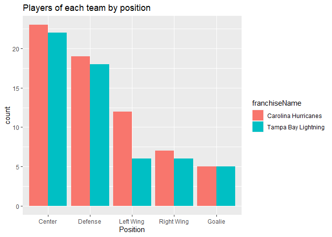

```r
ggplot(rosterTBLvsCH, aes(positionCode, fill = franchiseName)) +
  geom_bar(position = "dodge") +
  labs(title = "Players of each team by position", x = "Position")
```

## Numerical Summaries

Suppose we want to get a preliminary investigation on the data for skaters, by team or for all skaters with a specific position. The `getSkaterSummary` function will take in the team and position for active skaters that we are interested in and outputs a the five number summary for the assists, goals, points, and penalty Minutes.

```r
getSkaterSummary <- function(position, name = NULL){
  skatePosition <- getEndpoint("skater", name)
  new <- skatePosition %>% filter(activePlayer == TRUE & positionCode == position) %>%
    select(assists, goals, points, penaltyMinutes)
  if (position == "C")
     type = "Center"
  if (position == "D")
     type = "Defense"
  if (position == "L")
     type = "Left Wing"
  if (position == "R")
     type = "Right Wing"
  if (is.null(name)){
    main <- paste0("Summary of ", type)
  }
  else {
    main <- paste0("Summary of ", type, " for ", name)
  }
  kable(apply(new, 2, summary), caption = main)
}
```

```r
getSkaterSummary(position = "C", name = "Carolina Hurricanes")
```

|  | assists | goals | points | penaltyMinutes |
| --- | --- | --- | --- | --- |
| Min. | 0.0 | 0.00000 | 0.0000 | 0.00000 |
| 1st Qu. | 4.5 | 2.50000 | 7.5000 | 8.00000 |
| Median | 27.0 | 19.00000 | 45.0000 | 35.00000 |
| Mean | 61.0 | 42.17391 | 103.1739 | 75.43478 |
| 3rd Qu. | 52.0 | 42.00000 | 94.0000 | 70.50000 |
| Max. | 453.0 | 322.00000 | 775.0000 | 678.00000 |

Summary of Center for Carolina Hurricanes

```r
getSkaterSummary(position = "D", name = "Carolina Hurricanes")
```

|  | assists | goals | points | penaltyMinutes |
| --- | --- | --- | --- | --- |
| Min. | 0.00000 | 0.00000 | 0.00000 | 0.00000 |
| 1st Qu. | 4.50000 | 0.50000 | 4.50000 | 9.50000 |
| Median | 13.00000 | 4.00000 | 20.00000 | 30.00000 |
| Mean | 38.78947 | 12.84211 | 51.63158 | 50.15789 |
| 3rd Qu. | 57.50000 | 15.50000 | 73.00000 | 64.50000 |
| Max. | 173.00000 | 85.00000 | 258.00000 | 265.00000 |

Summary of Defense for Carolina Hurricanes

```r
getSkaterSummary(position = "L", name = "Carolina Hurricanes")
```

|  | assists | goals | points | penaltyMinutes |
| --- | --- | --- | --- | --- |
| Min. | 0.00 | 0.00 | 0.00 | 4.00000 |
| 1st Qu. | 19.75 | 11.50 | 30.25 | 29.00000 |
| Median | 25.50 | 19.00 | 45.50 | 58.00000 |
| Mean | 48.50 | 39.25 | 87.75 | 68.66667 |
| 3rd Qu. | 38.50 | 39.00 | 77.50 | 81.00000 |
| Max. | 181.00 | 204.00 | 379.00 | 268.00000 |

Summary of Left Wing for Carolina Hurricanes

```r
getSkaterSummary(position = "R", name = "Carolina Hurricanes")
```

|  | assists | goals | points | penaltyMinutes |
| --- | --- | --- | --- | --- |
| Min. | 0.00000 | 0.00000 | 0.00000 | 0.00000 |
| 1st Qu. | 0.00000 | 0.00000 | 0.00000 | 0.00000 |
| Median | 1.00000 | 0.00000 | 1.00000 | 6.00000 |
| Mean | 20.42857 | 15.71429 | 36.14286 | 38.71429 |
| 3rd Qu. | 30.50000 | 25.50000 | 56.00000 | 52.50000 |
| Max. | 81.00000 | 59.00000 | 140.00000 | 160.00000 |

Summary of Right Wing for Carolina Hurricanes

## Box plot

If we were interested in seeing the points per game of the skaters. The players with positions center, defense, and left wing have similar plots between the two teams. Some slight differences is the center on the Tampa Bay Lightnings with over 0.9 points per game. On the Carolina Hurricanes, the defense player with over 0.6 points per game is an outlier, but for Tampa Bay, the player with over 0.6 points per game is still within the whisker of the boxplot. The most noticable difference between the two teams are in the right wing boxplot. First the inter quartile range for the Tampa Bay Lightning is much smaller than the Carolina Hurricanes and they also have an outlier that is over 0.9 points per game.

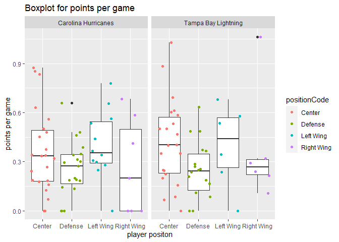

```r
ggplot(skateTBLvsCH, aes(positionCode, ppg)) +
  geom_boxplot() +
  geom_jitter(aes(color = positionCode)) +
  facet_wrap(~franchiseName) +
  labs(title = "Boxplot for points per game", x = "player positon", y = "points per game")
```

## Histogram

### Points per game

Using a historgram we can roughly see what the density of the player’s points per game for each team. The two teams have similar density lines, with a slightly right skewed shape. We can also see Tampa Bay Lighting has players who score at least one point per game they play, while the Carolina Hurricanes all stay below one point per game.

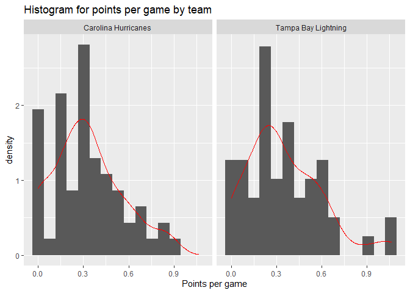

```r
#Separated histograms for each team
ggplot(skateTBLvsCH, aes(ppg)) +
  geom_histogram(aes(y = ..density..), bins = 15) +
  geom_density(color = "red") +
  facet_wrap(~franchiseName) +
  labs(title = "Histogram for points per game by team", x = "Points per game")
```

### Win Percent

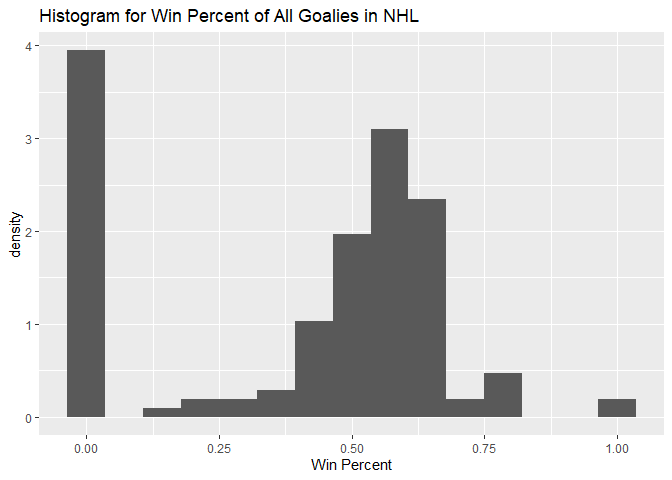

```r
#A histogram for all goalies in the NHL
ggplot(allGoalie, aes(winPercent)) +
  geom_histogram(aes(y = ..density..), bins = 15) +
  labs(title = "Histogram for Win Percent of All Goalies in NHL", x = "Win Percent")
```

## Scatter plot

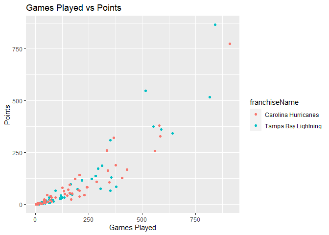

```r
ggplot(skateTBLvsCH, aes(gamesPlayed, points, col = franchiseName)) +
  geom_point() +
  labs(title = "Games Played vs Points", x = "Games Played", y = "Points")
```